# Datathon

2/22/2019

## Research question: Which states are the most vulnerable to droughts?

### Methodology

#### We look at what are the states that severe droughts happen, then explore on what are the industries that earnings decrease is mostly related to droughts. Additionally we also look at the water quality on average in different states in order to come up with the conclusion of what are the states that are most vulnerable.

#### The methodologies we use are random sampling and linear models to analyse the relationship between industry specific earnings and droughts.

### Read the datasets

```r
chemicals <- read.csv("chemicals.csv")
summary(chemicals)
```

```
##       fips                       county           state
##  Min.   : 6001   Polk County        : 10644   PA     : 86876
##  1st Qu.:19109   Washington County  : 10275   FL     : 74807
##  Median :33005   Marion County      :  9941   NY     : 71040
##  Mean   :30190   Hillsborough County:  9529   CA     : 65449
##  3rd Qu.:42027   Jefferson County   :  8915   WA     : 60681
##  Max.   :55141   Orange County      :  8738   MO     : 46051
##                  (Other)            :824277   (Other):477415
##       year                      cws_name            pws_id
##  Min.   :1999   WHISPERING PINES MHP:   261   FL6411132:    99
##  1st Qu.:2005   GREEN ACRES MHP     :   224   CO0118015:    98
##  Median :2009   MOUNTAIN VIEW MHP   :   209   FL6515234:    94
##  Mean   :2009   COUNTRY ESTATES     :   179   FL6521784:    94
##  3rd Qu.:2013   COUNTRYSIDE MHP     :   173   VT0005290:    94
##  Max.   :2016   COUNTRY ESTATES MHP :   171   VT0020455:    94
##                 (Other)             :881102   (Other)  :881746
##    pop_served              chemical_species
##  Min.   :      0   Arsenic         :142001
##  1st Qu.:    118   DEHP            : 72825
##  Median :    485   Halo-Acetic Acid:146132
##  Mean   :  10732   Nitrates        :329372
##  3rd Qu.:   3030   Trihalomethane  :154258
##  Max.   :8271000   Uranium         : 37731
##
##               contaminant_level      unit_measurement      value
##  Greater than MCL      : 13545   micrograms/L:882319   Min.   :     0.0
##  Less than or equal MCL:503954                         1st Qu.:     1.0
##  Non Detect            :364820                         Median :    11.3
##                                                        Mean   :   426.6
##                                                        3rd Qu.:   140.0
##                                                        Max.   :150000.0
##
```

```r
droughts <- read.csv("droughts.csv")
```

#### First, we want to get a sense of what are the states that suffer from severe droughts.

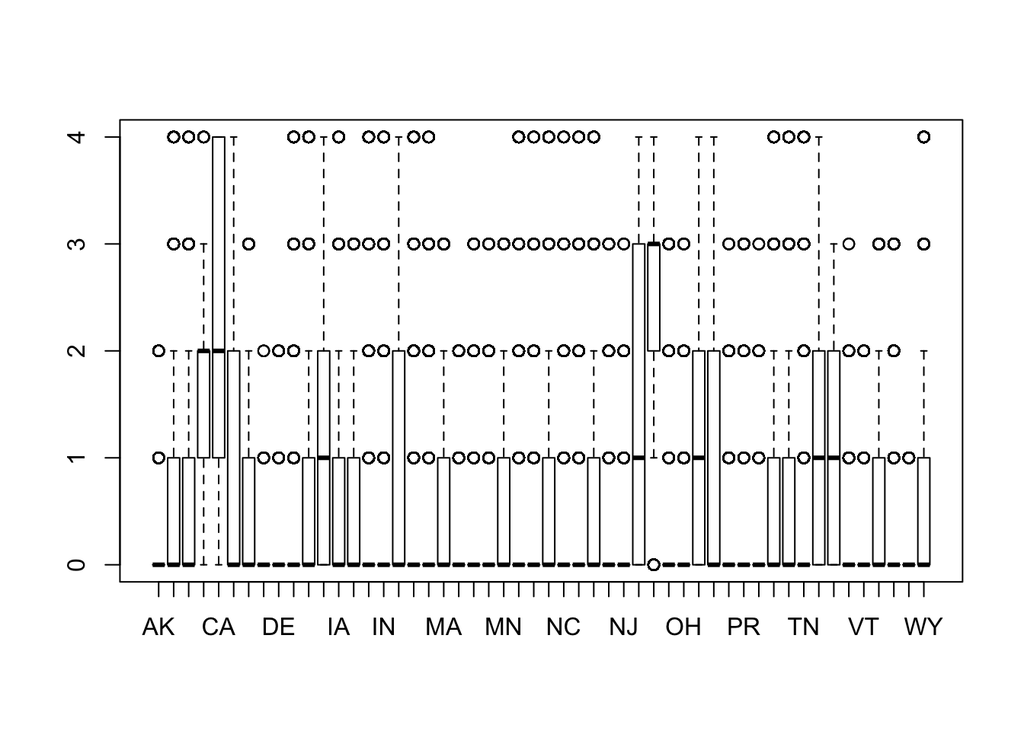

```r
droughts$vul <- ifelse(droughts$d4>0, 4, ifelse(droughts$d3>0, 3, ifelse(droughts$d2>0, 2, ifelse(droughts$d1>0,1,0))))
plot(droughts$state,droughts$vul)
```

```r
library(tidyverse)
```

```r
library(ggplot2)
droughts %>% select(county, state, d4) %>% arrange(desc(d4)) %>% top_n(10)
```

```
##               county state     d4
## 1   McPherson County    NE 100.01
## 2   McPherson County    NE 100.01
## 3   McPherson County    NE 100.01
## 4   McPherson County    NE 100.01
## 5   McPherson County    NE 100.01
## 6   McPherson County    NE 100.01
## 7   McPherson County    NE 100.01
## 8   McPherson County    NE 100.01
## 9   McPherson County    NE 100.01
## 10  McPherson County    NE 100.01
## 11  McPherson County    NE 100.01
## 12  McPherson County    NE 100.01
## 13  McPherson County    NE 100.01
## 14  McPherson County    NE 100.01
```

[output cut: 35 more lines]

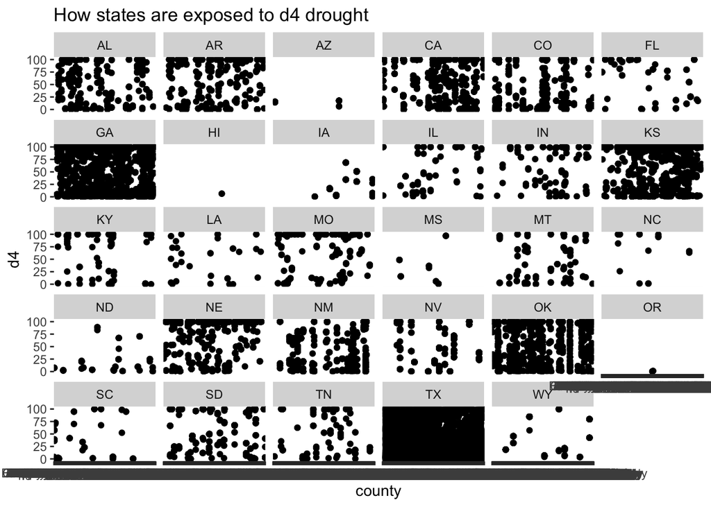

```r
droughts %>% filter(d4 != 0) %>% select(county, state, d4) %>% ggplot() + geom_point(mapping=aes(x=county, y= d4)) + facet_wrap(~state) + ggtitle("How states are exposed to d4 drought")
```

#### One of the shortcomings of these facet wrap is that it takes d4 only as the indicator of severe droughts. Also, part of the reason for the density of points in TX is because it has more data points than the others. Despite these, however, this graph still shows us what are the states with more d4 happening than others.

### What industries are mostly affected by droughts?

#### Dummy model looks at how fish mining is affected.

```r
earnings <- read.csv("earnings.csv")
#head(earnings)
library(tidyverse)

set.seed(123)
sample_size <- floor(nrow(droughts) * 0.01)
sample_id <- sample(1:nrow(droughts), sample_size)
sample <- droughts[sample_id,]
# A random sample of 1% of data is chosen from the droughts, such that the following models will run quicklier.

prbl2 <- merge(earnings, sample, by="state")
prbl2$agri <- prbl2$total_agri_fish_mine
dummymodel <- lm(agri ~ none + d1 + d2 + d3 + d4, data = prbl2)
summary(dummymodel)
```

```
##
## Call:
## lm(formula = agri ~ none + d1 + d2 + d3 + d4, data = prbl2)
##
## Residuals:
##    Min     1Q Median     3Q    Max
## -32481  -8288  -1870   6484 150230
##
## Coefficients:
##               Estimate Std. Error  t value Pr(>|t|)
## (Intercept) 32442.1034    13.0881 2478.751  < 2e-16 ***
## none           -0.5164     0.1498   -3.448 0.000565 ***
## d1             16.8449     0.2335   72.143  < 2e-16 ***
## d2             25.3855     0.2427  104.577  < 2e-16 ***
## d3             16.0475     0.2908   55.186  < 2e-16 ***
## d4             10.3210     0.4013   25.716  < 2e-16 ***
## ---
## Signif. codes:  0 '***' 0.001 '**' 0.01 '*' 0.05 '.' 0.1 ' ' 1
##
## Residual standard error: 12340 on 6640468 degrees of freedom
##   (43261 observations deleted due to missingness)
## Multiple R-squared:  0.004367,   Adjusted R-squared:  0.004366
## F-statistic:  5825 on 5 and 6640468 DF,  p-value: < 2.2e-16
```

#### Contrary to what we thought, fish mining workers love drought. So fish mining industry is not negatively affected even during periods of water resource shortage.

### Model 1 looks at fish hunt.

```r
model1 <- lm(agri_fish_hunt ~ none + d1 + d2 + d3 + d4, data = prbl2)
summary(model1)
```

```
##
## Call:
## lm(formula = agri_fish_hunt ~ none + d1 + d2 + d3 + d4, data = prbl2)
##
## Residuals:
##    Min     1Q Median     3Q    Max
## -24021  -5837   -823   4912 223658
##
## Coefficients:
##               Estimate Std. Error  t value Pr(>|t|)
## (Intercept) 26467.3183    10.7321 2466.192  < 2e-16 ***
## none           -1.2572     0.1229  -10.234  < 2e-16 ***
## d1              0.5340     0.1913    2.791  0.00525 **
## d2              0.2094     0.1989    1.053  0.29231
## d3              0.2353     0.2381    0.988  0.32304
## d4             -1.0636     0.3286   -3.237  0.00121 **
## ---
## Signif. codes:  0 '***' 0.001 '**' 0.01 '*' 0.05 '.' 0.1 ' ' 1
##
## Residual standard error: 10070 on 6581077 degrees of freedom
##   (102652 observations deleted due to missingness)
## Multiple R-squared:  4.705e-05,  Adjusted R-squared:  4.629e-05
## F-statistic: 61.93 on 5 and 6581077 DF,  p-value: < 2.2e-16
```

### Model 2 looks at construction.

```r
model2 <- lm(construction ~ none + d1 + d2 + d3 + d4, data = prbl2)
summary(model2)
```

```
##
## Call:
## lm(formula = construction ~ none + d1 + d2 + d3 + d4, data = prbl2)
##
## Residuals:
##    Min     1Q Median     3Q    Max
## -29919  -4950   -440   4273  62028
##
## Coefficients:
##               Estimate Std. Error t value Pr(>|t|)
## (Intercept) 32027.9113     9.1971 3482.40   <2e-16 ***
## none            3.9145     0.1053   37.19   <2e-16 ***
## d1             -1.9047     0.1648  -11.56   <2e-16 ***
## d2             -5.2017     0.1711  -30.40   <2e-16 ***
## d3             -7.6110     0.2035  -37.41   <2e-16 ***
## d4             -4.9787     0.2798  -17.80   <2e-16 ***
## ---
## Signif. codes:  0 '***' 0.001 '**' 0.01 '*' 0.05 '.' 0.1 ' ' 1
##
## Residual standard error: 7501 on 4950337 degrees of freedom
##   (1733392 observations deleted due to missingness)
## Multiple R-squared:  0.002203,   Adjusted R-squared:  0.002202
## F-statistic:  2186 on 5 and 4950337 DF,  p-value: < 2.2e-16
```

#### Construction is severely impacted by the drought. As we know, construction generally consumes much water resources. That may be why when there is a drought these industries suffer.

### Model 3 below looks at financial services industry.

```r
model3 <- lm(fin_ins_realest ~ none + d1 + d2 + d3 + d4, data = prbl2)
summary(model3)
```

```
##
## Call:
## lm(formula = fin_ins_realest ~ none + d1 + d2 + d3 + d4, data = prbl2)
##
## Residuals:
##    Min     1Q Median     3Q    Max
## -32068  -6344  -1705   4296 216503
##
## Coefficients:
##               Estimate Std. Error  t value Pr(>|t|)
## (Intercept) 33895.0438    11.3445 2987.793  < 2e-16 ***
## none            0.1696     0.1298    1.307    0.191
## d1             -0.9030     0.2030   -4.448 8.66e-06 ***
## d2             -3.9788     0.2116  -18.806  < 2e-16 ***
## d3             -1.7055     0.2534   -6.730 1.69e-11 ***
## d4              6.7260     0.3504   19.194  < 2e-16 ***
## ---
## Signif. codes:  0 '***' 0.001 '**' 0.01 '*' 0.05 '.' 0.1 ' ' 1
##
## Residual standard error: 10670 on 6594740 degrees of freedom
##   (88989 observations deleted due to missingness)
## Multiple R-squared:  0.0001575,  Adjusted R-squared:  0.0001568
## F-statistic: 207.8 on 5 and 6594740 DF,  p-value: < 2.2e-16
```

#### We can see that finance, insurance and real estate industries are greatly impacted by d1, d2 and d3 level of droughts. For example, if there is 1% more population affected by d2, there will be 3.97 decrease in earnings of financial industries. To the contrary, however, a most severe d4 drought has a positive impact on these industries. What’s more, if there is no drought, financial services are not going to be significantly impacted.

#### Since construction is clearly strongly affected by the drought, we want to see which states are primary focused on this industry.

```r
industry_occupation <- read.csv("industry_occupation.csv")

construct_pop = industry_occupation %>% group_by(state) %>% summarize(num = sum(construction), perct=num/sum(total_employed)) %>% arrange(desc(perct)) %>% top_n(10)
construct_pop
```

```
## # A tibble: 10 x 3
##    state     num  perct
##    <fct>   <dbl>  <dbl>
##  1 MT     156325 0.0829
##  2 LA     810856 0.0793
##  3 TX    5741994 0.0790
##  4 AK     122846 0.0777
##  5 ND     104697 0.0737
##  6 WY      44507 0.0731
##  7 HI     328532 0.0727
##  8 CO    1133205 0.0724
##  9 OK     530526 0.0705
## 10 ID     217200 0.0684
```

```r
#edu_pop = industry_occupation %>% group_by(state) %>% summarize(num = sum(edu_health), perct=num/sum(total_employed)) %>% arrange(desc(perct)) %>% top_n(10)
```